# Part II - Prosper Loans Dataset

## by Franck Loïc NOUMOU TCHOMEGNI

## Investigation Overview

Dans cette analyse, je voulais comprendre deux choses :

- Quels sont les facteurs qui influencent la note Prosper ?
- Les facteurs qui peuvent être utilisés pour prédire le défaut de crédit.

## Dataset Overview

Il y avait trois problèmes majeurs avec les données :

- Prosper a commencé à utiliser la notation Prosper à partir de 2009. Avant 2009, Prosper utilisait la note de crédit. J'ai dû supprimer entièrement les points de données antérieurs à 2009
- La plupart des prêts dans l'ensemble de données sont en fait des prêts en cours et ne peuvent pas être utilisés pour déterminer comment le défaut de crédit peut être prédit. Les crédits en défaut ont été divisés en deux catégories imputés et en défaut (voir sous-diapositive). Pour résoudre ce problème, j'ai supprimé tous les prêts actuels et fusionné les crédits imputés et en défaut.
- Le revenu mensuel déclaré avait un nombre inhabituellement élevé de valeurs aberrantes et une très large plage de valeurs allant de 0 à 1 750 000. Pour résoudre ce problème, j'ai supprimé toutes les données au-dessus de trois écarts-types par rapport à la moyenne.

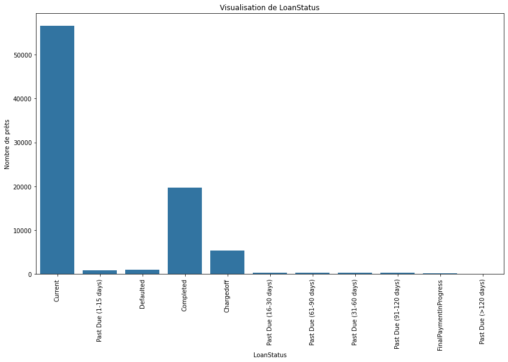

```python
plt.figure(figsize=[14, 8])
plt.xticks(rotation=90)
plt.title('Visualisation de LoanStatus')
sb.countplot(data = df_sub, x = 'LoanStatus', color = color)
plt.xlabel('LoanStatus')
plt.ylabel('Nombre de prêts');
```

Après nettoyage, il y a 26 005 prêts dans l'ensemble de données : 19 664 prêts achevés et 6 341 en défaut.

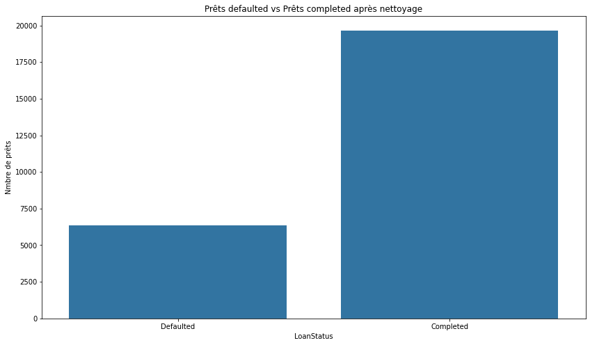

```python
plt.figure(figsize=[14, 8])
plt.title('Prêts defaulted vs Prêts completed après nettoyage')
sb.countplot(data = df_sub, x = 'LoanStatus', color = color)
plt.ylabel('Nmbre de prêts');
```

Après nettoyage, la visualisation de `StatedMonthlyIncome` semble à peu près normale avec une forte inclinaison vers la droite et une moyenne de 5328 USD et une valeur maximale de 30416,67 USD.

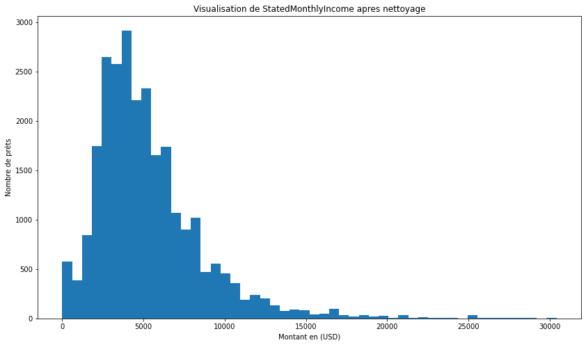

```python
plt.figure(figsize=[14, 8])
plt.title('Visualisation de StatedMonthlyIncome apres nettoyage')
plt.ylabel('Nombre de prêts')
plt.xlabel('Montant en (USD)')
plt.hist(data=df_sub, x='StatedMonthlyIncome', bins=50, color=color);
```

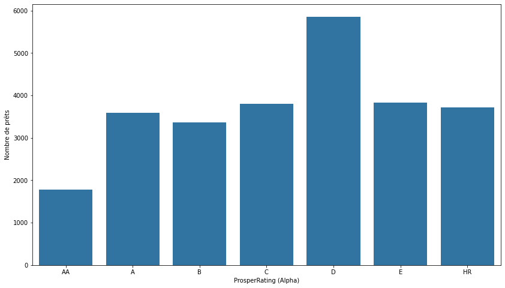

```python
plt.figure(figsize=[14,8])
sb.countplot(data=df_sub, x='ProsperRating (Alpha)', color=color)
plt.ylabel('Nombre de prêts');
```

La tendance générale est que plus la note Prosper est faible, plus il y a de défauts sur les crédits, à l'exception de la note **D** qui s'avère la note la plus courante parmi les crédits en défaut.

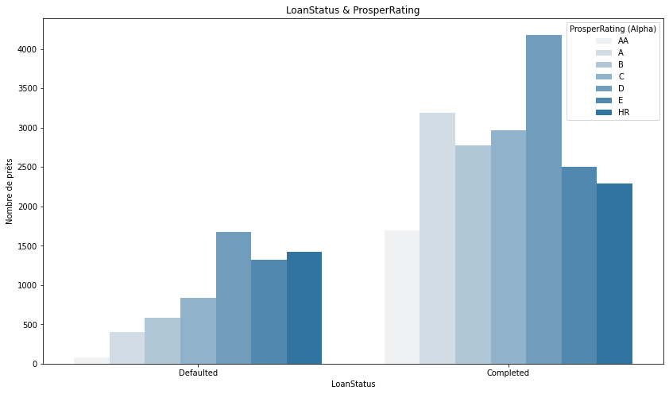

```python
plt.figure(figsize=[14, 8])
plt.title('LoanStatus & ProsperRating')
sb.countplot(data=df_sub, x='LoanStatus', hue='ProsperRating (Alpha)', color=color)
plt.ylabel('Nombre de prêts');
```

Les personnes ayant le statut d'emploi **Not employed** ou **Self-employed** sont plus susceptibles de faire défaut sur le crédit :

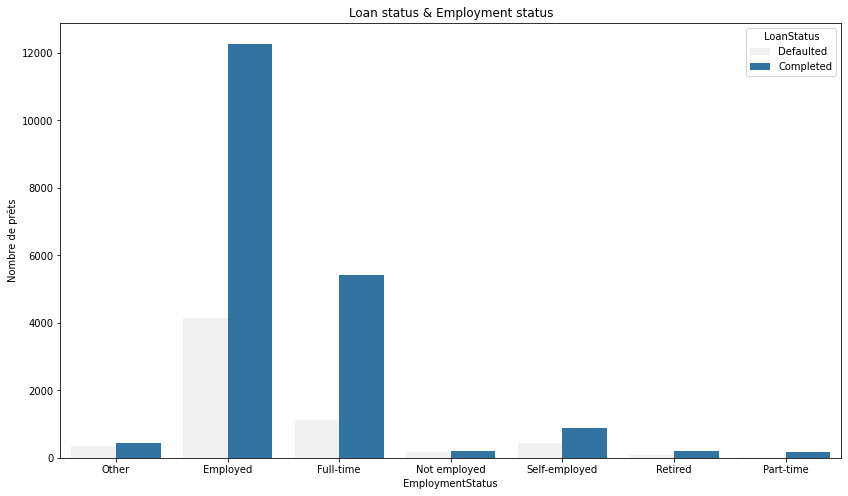

```python
plt.figure(figsize = [14, 8])
plt.title('Loan status & Employment status')
sb.countplot(data=df_sub, x='EmploymentStatus', hue='LoanStatus', color=color)
plt.ylabel('Nombre de prêts');
```

Les prêts à long terme (60 mois) ont la plus grande proportion de crédits **Defaulted**.

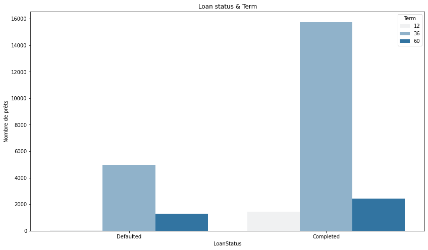

```python
plt.figure(figsize=[14,8])
plt.title('Loan status & Term')
sb.countplot(data=df_sub, x='LoanStatus', hue='Term', color=color)
plt.ylabel('Nombre de prêts');
```

Les emprunteurs ayant une cote Prosper élevée ont tendance à emprunter davantage, les prêts **Defaulted** ont tendance à être plus importants que ceux **Completed** pour les emprunteurs à cote élevée. Les emprunteurs à faible notation, en revanche, ont tendance à emprunter moins et leurs crédits **Defaulted** sont généralement aussi importants que **Completed**.

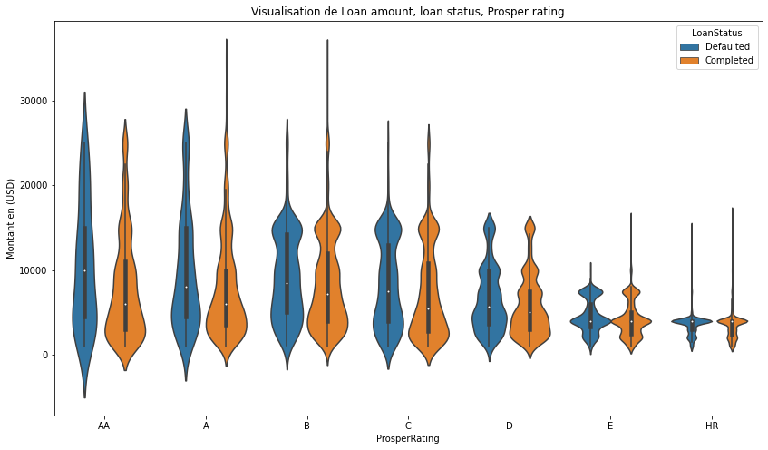

```python
plt.figure(figsize = [14, 8])
plt.title('Visualisation de Loan amount, loan status, Prosper rating')
sb.violinplot(data=df_sub, x='ProsperRating (Alpha)', y='LoanOriginalAmount', hue='LoanStatus')
plt.xlabel('ProsperRating')
plt.ylabel('Montant en (USD)');
```

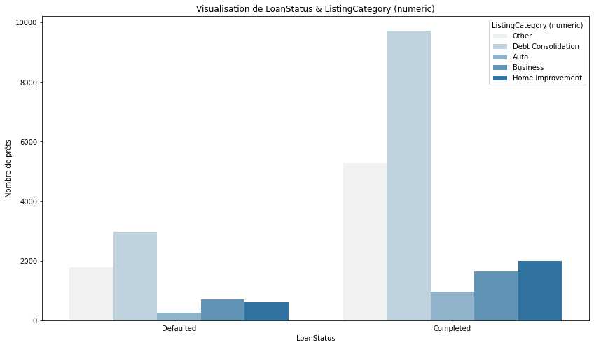

```python
plt.figure(figsize = [14, 8])
plt.title('Visualisation de LoanStatus & ListingCategory (numeric)')
sb.countplot(data=df_sub, x='LoanStatus', hue='ListingCategory (numeric)', color=color)
plt.ylabel('Nombre de prêts');
```

Les personnes ayant une note élevée ont tendance à avoir un **StatedMonthlyIncome** plus élevé.

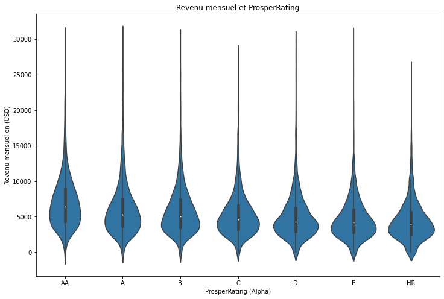

```python
plt.figure(figsize = [12, 8])
plt.title('Revenu mensuel et ProsperRating')
sb.violinplot(data = df_sub, x = 'ProsperRating (Alpha)', y = 'StatedMonthlyIncome', color = color)
plt.xlabel('ProsperRating (Alpha)')
plt.ylabel('Revenu mensuel en (USD)');
```

Plus la cote Prosper diminue, plus la proportion d'individus ayant `EmploymentStatus` **Not employed**, **Self-employed** et **Retired** augmente.

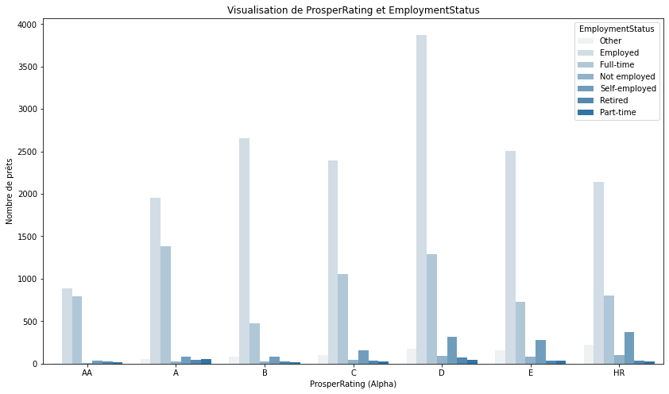

```python
plt.figure(figsize = [14, 8])
plt.title('Visualisation de ProsperRating et EmploymentStatus')
sb.countplot(data = df_sub, x = 'ProsperRating (Alpha)', hue = 'EmploymentStatus', color=color)
plt.ylabel('Nombre de prêts');
```

### Submission

   ```
   zip -r my_project.zip .
   ```